# GBI6 - BIOINFORMÁTICA

EXAMEN FINAL

Salcán Shirley

2022-03-17

**Bienvenidos al examen final de GBI6 - Bioinformática.**

# CONTENIDO DE LA EVALUACIÓN

Los contenidos de esta evaluación corresponden a los temas de R revisados en el curso:

- Tipos de datos
- Instalación y uso de librerías.
- Estructuras de control
- Funciones
- Manipulación de datos
- Estadística básica
- Visualización de datos

# INDICACIONES GENERALES

Esta permitido consultar todo material disponible: diapositivas, google…Sin embargo **NO** esta permitido consultar a sus colegas.

Ustedes estan utilizando el R Markdown. Las instruciones son:

- Creen una carpeta en su computador con el nombre “GBI6_ExamenFinal” donde guarden este cuaderno .Rmd.
- Cree un subdirectorio de nombre “data” donde guarde la data que van a utilizar.
- Cree un subdirectorio de nombre “results” donde guarde la tablas y figuras generadas del análisis.
- Definan a esa carpeta como su directorio de trabajo.
- Arriba, **solamente** donde dice “author”, deben llenar sus nombres.
- Los codigos deben ser escritos dentro de las cajas que inician y terminan con ``` o dentro de las cajas indicadas abajo de las preguntas.
- Al final del examen deben utilizar el comando “Knit” para generar un archivo .html
- Es recomendable crear una copia de este script guía.
- Genere controles de la versión para cada una de las preguntas con la leyenda “Nombre Apellido, resuelve el ejercicio XX”.
- Copie y peque la dirección de su repositorio de GitHub en la actividad **“ExamenFinal”**.
- Asegúrese de responder explícitamente cada una de las preguntas.

Para comprender la data de esta evaluación se requiere conocer el significado de algunos acrónimos de los tipos de cancer como indica el [Broad Institute Cancer Names](https://gdac.broadinstitute.org/). Asimismo revise la información de ayuda para `expresionsTCGA`. La data contiene las columnas:

- **bcr_patient_barcode**: es el identificador del paciente.
- **dataset**: es el identificador del tipo de cancer del paciente.
- **resto de columnas**: nivees de expresión de los diferentes mRNA de los genes que están como nombre de columna (para este análisis se han seleccionado solamente 7 de ellos).

# PREGUNTAS

## **Pregunta 1: MANIPULACIÓN DE DATOS [4 PUNTOS]**

### [0.5 PUNTOS] 1.1 Defina su directorio de trabajo.

```r
getwd()
```

```
## [1] "C:/Users/Usuario/Desktop/Michell Universidad/6to Semestre/Bioinformática/GBI6_ExamenFinal"
```

### [0.5 PUNTOS] 1.2. Cargue la data “mRNA_expr.csv”

```r
df <- read.csv("data/mRNA_expr.csv")
```

### [1 PUNTO] 1.3 Cree una función de nombre `long_df` para transformar la data `df` de la forma wide a long.

```r
library("tidyverse")
library("dplyr")
long_df <- function(table){
  a <- table %>% pivot_longer(!c(bcr_patient_barcode, dataset), names_to= "gen", values_to ="expresion_level")
  a
}
```

### [1 PUNTO] Genere la data `df_long` utilizandola función `long_df`.

La tabla resultante tendrá tres columnas: `dataset, gen, expresion_level`.

```r
df_long <- long_df(df)
df_long <- df_long[,-1]
head(df_long, n=5)
```

```
## # A tibble: 5 x 3
##   dataset gen   expresion_level
##   <chr>   <chr>           <dbl>
## 1 BRCA    GATA3            2.87
## 2 BRCA    PTEN             1.36
## 3 BRCA    XBP1             2.98
## 4 BRCA    ESR1             3.08
## 5 BRCA    MUC1             1.65
```

### [0.5 PUNTOS] 1.5 A partir de la data `df_long`, genere un **Descriptive table** (librería `sjPlot`) y guárdelo en el subdirectorio “result” con el nombre **mRNA_expr_summary.doc** (previamente debe seleccionar las celdas adecuadas con funciones de la librería `dplyr` en conjunto con el operador `%>%`).

```r
library("sjPlot")
library("sjmisc")
BRCA <- df_long %>% group_by(dataset,gen)
TDesc <- descr(x=BRCA, out="browser",file="results/mRNA_expr_summary.doc")
```

### [0.5 PUNTOS] 1.6 Interprete los resultados de la tabla resultante de la sección 1.5.

```latex
# Resultados estadísticos
#En base a las tablas se observa que existen una mayor cantidad de datos para el
#Carcinoma invasivo de mama (BRCA) en el cual se expresa con mayor nivel el gen
#ESR1 con un promedio de 2.3. Por otro lado para la cohorte pan riñón (KIPAN),
#existe una frecuencia de 88 observaciones, con una mayor expresion del gen
#PTEN con un promedio de 0,72. Mientras que para el Carcinoma renal de células
#claras renales (KIRP) existen unicamente 16 observaciónes con un alto nivel de
#expresión del men PTEN. Por el contrario, para el Carcinoma de células escamosas
#de pulmón (LUSC) existen 154 observaciones de las cuales el gen con mayor
#expresión fue MUC1 con un promedio de 0.56. En contraste el
#Cistoadenocarcinoma seroso de ovario (OV) tiene 561 observaciones, y se expresa
#con mayor frecuenta el gen FN1 con un promedio de 1,33 en los niveles de
#expresión. Finalmente, el #Carcinoma de endometrio del cuerpo uterino (UCEC)
#posee 54 observaciones, y se expresa mayoritariamente el gen ESR1 con un
#promedio de 2,17.
```

## **Pregunta 2 VISUALIZACION DE DATOS [5 PUNTOS]**

Para esta pregunta tiene que utilizar la data `df_long`.

### [1 PUNTO] 2.1 Cree la funcion `tcga_boxplots` para visualizar boxplots y jitterplots. El único parámetro de la función es `dataset`. La función debe crear un boxplot de los niveles de expresión para cada gen.

```r
library(ggplot2)
tcga_boxplots <- function(data){
  b <- df_long %>% filter (dataset == data)
  c <- b %>% ggplot(aes(x=gen,y=expresion_level, color = gen)) +
  geom_boxplot() + geom_jitter ()
}
```

### [0.5 PUNTOS] 2.2 Utilizando la función `lapply()` genera la lista `cancertype_boxplots` con las gráficas para cada tipo de cancer (cada tipo de dataset).

```r
e <- unique(df_long$dataset) #Tomamos los datos unicos de la columna dataset
cancertype_boxplots <- lapply(e, tcga_boxplots)
o <- length(cancertype_boxplots)
print (paste("El número de elementos de la lista cancertype_boxplots es: ", o))
```

```
## [1] "El número de elementos de la lista cancertype_boxplots es:  6"
```

```r
print ("El tercer elemento de la lista es:")
```

```
## [1] "El tercer elemento de la lista es:"
```

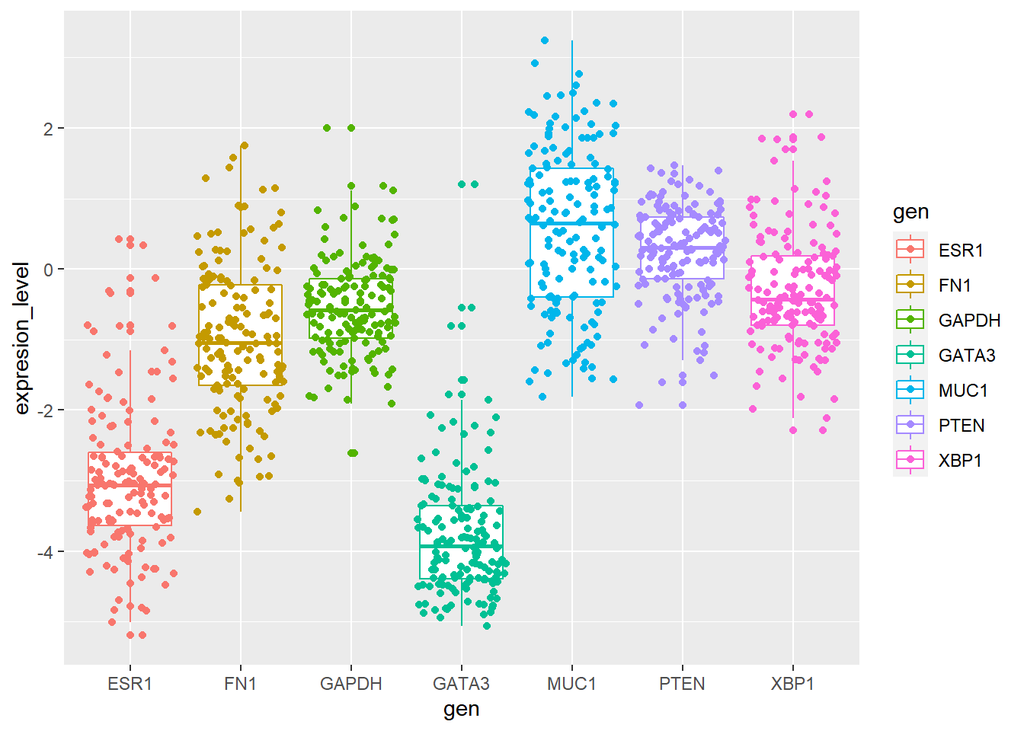

```r
cancertype_boxplots[[3]]
```

### [0.5 PUNTOS] 2.3 Guarde en el subdirectorio `result` el tercer plot de la lista `cancertype_boxplots` con el nombre `boxplot3.png`. La definición de a figura debe ser de 300dpi.

```r
d <- cancertype_boxplots[[3]]
ggsave(filename = "results/boxplot3.png", units="in",
dpi = 300,limitsize=TRUE)
```

### [1 PUNTO] 2.4 Escriba la función `reg_gen_expression`, con el parámetro `gen`. En este caso la función visualizará una gráfica de nube de puntos (geom_point) y una regresión por tipo de “dataset”. La gráfica será de comparación de gen1 con gen2; por ejemplo en el eje “x” `GATA3` y en el eje “y”” `FN1`.

```r
reg_gen_expression <- function(d){
  genx=d[1]
  geny=d[2]
  g <- df_long %>% filter (gen == genx)
  j <- df_long %>% filter (gen == geny)
  k <- cbind(g,j) #combinamos las dos tablas de resultado de filter
  r <- tibble("dataset"=k[,1],"gen1"=k[,3],"gen2"=k[,6]) #generamos una nueva tabla unicamente con las columnas 1, 3 y 6, y les cambiamos de nombre
  h <- r %>% ggplot(aes(x = gen1, y = gen2, color=dataset)) + geom_point() + geom_smooth(method=lm, se=FALSE)
  h
}
```